# Stock Market EDA Project Documentation

#### **Time Series Analysis**

Finally, I conducted a time series analysis, observing how average close price, trading volume,volatility and market return evolved over time across sectors and individual stocks. This revealed growth trends and volatility levels, showcasing the dynamic nature of the stock market. Through this methodology, I gained deep insights into market dynamics, laying a foundation for identifying investment opportunities and understanding market risk.

**Time series Analysis on a Sector Level**

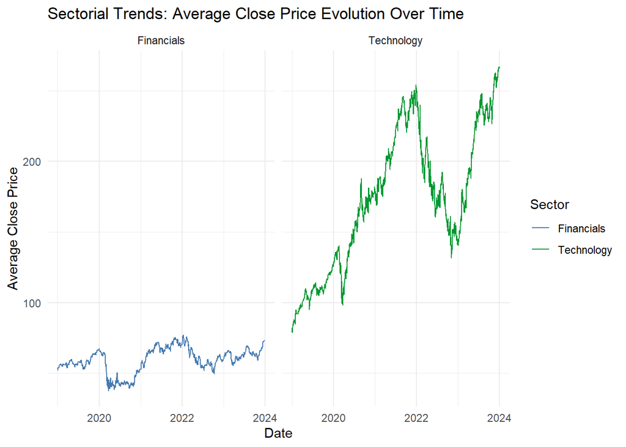

```r
# On a sector level
# 1 Trend of Average Close Price Over the Years
stock_market_data %>% group_by(Date, Sector) %>%
  summarise(Average_Close = mean(Close)) %>%
  ggplot(aes(x=Date, y=Average_Close, color=Sector))+
  geom_line() +
  scale_color_manual(values =
                      c("Financials" = "#467ab0",
                        "Technology" = "#009933")) +
  labs(title = "Sectorial Trends: Average Close Price Evolution Over Time",
       x="Date",y="Average Close Price") +
  facet_wrap( ~ Sector) +
  theme_minimal()
```

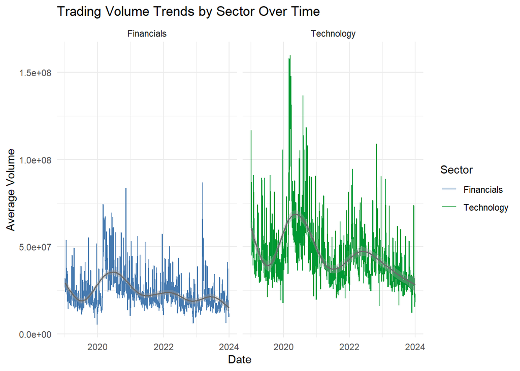

```r
# 2 Trend of Average Volume Over the Years
stock_market_data %>% group_by(Date, Sector) %>%
  summarise(Average_Volume = mean(Volume)) %>%
  ggplot(aes(x=Date, y=Average_Volume, color=Sector))+
  geom_line() +
  geom_smooth( size=0.7, color="#696969") +
  scale_color_manual(values =
                       c("Financials" = "#467ab0",
                         "Technology" = "#009933")) +
  labs(title = "Trading Volume Trends by Sector Over Time",
       x="Date",y="Average Volume") +
  facet_wrap( ~ Sector) +
  theme_minimal()
```

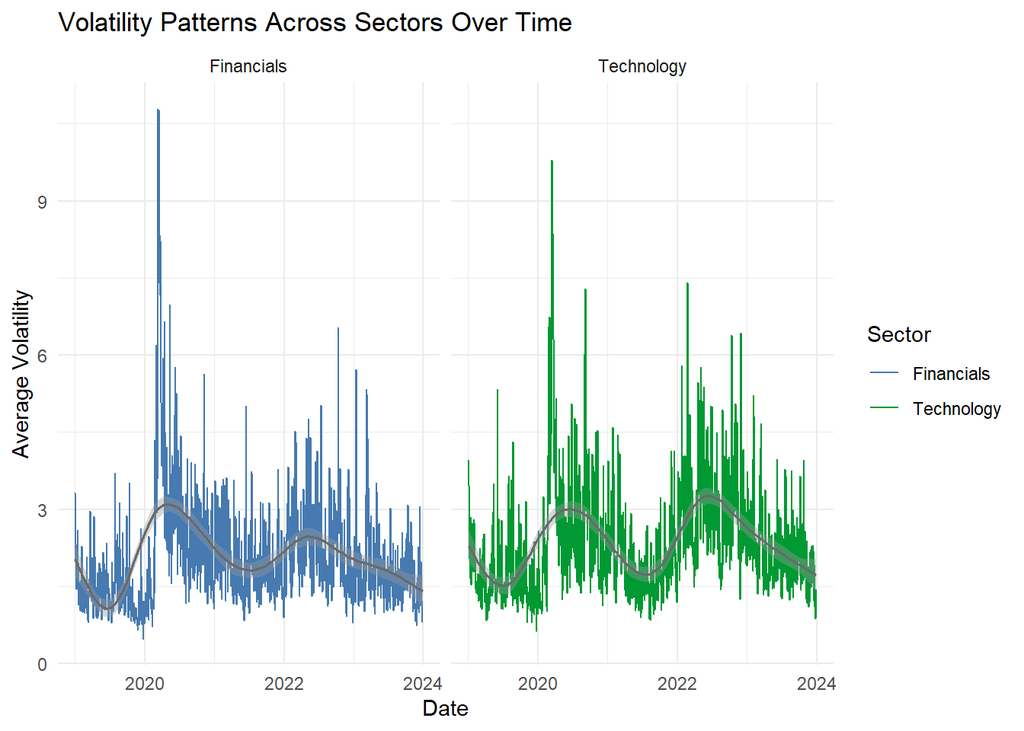

```r
# 3 Trend of Average Volatility Over the Years
stock_market_data %>% group_by(Date, Sector) %>%
  summarise(Average_Volatility = mean(Volatility)) %>%
  ggplot(aes(x=Date, y=Average_Volatility, color=Sector))+
  geom_line() +
  geom_smooth( size=0.7, color="#696969") +
  scale_color_manual(values =
                       c("Financials" = "#467ab0",
                         "Technology" = "#009933")) +
  labs(title = "Volatility Patterns Across Sectors Over Time", x="Date",y="Average Volatility") +
  facet_wrap( ~ Sector) +
  theme_minimal()
```